# dataset

```python
import pandas as pd
import seaborn as sns
```

In the article they indicate that they worked with red wine: "we have chosen redwine data for our study because of its popularity over the white wine."

Importing the red and white wine:

```python
# Define the relative path to the CSV file
relative_path_red_wine = 'wine+quality/winequality-red.csv'

# Read the CSV file using pandas
red_wine_df = pd.read_csv(relative_path_red_wine, delimiter=';')
```

```python
# Define the relative path to the CSV file
relative_path_white_wine = 'wine+quality/winequality-white.csv'

# Read the CSV file using pandas
white_wine_df = pd.read_csv(relative_path_white_wine, delimiter=';')
```

```python
# Display the first few rows of the red wine
print(red_wine_df.head())
```

```
   fixed acidity  volatile acidity  citric acid  residual sugar  chlorides  \
0            7.4              0.70         0.00             1.9      0.076
1            7.8              0.88         0.00             2.6      0.098
2            7.8              0.76         0.04             2.3      0.092
3           11.2              0.28         0.56             1.9      0.075
4            7.4              0.70         0.00             1.9      0.076

   free sulfur dioxide  total sulfur dioxide  density    pH  sulphates  \
0                 11.0                  34.0   0.9978  3.51       0.56
1                 25.0                  67.0   0.9968  3.20       0.68
2                 15.0                  54.0   0.9970  3.26       0.65
3                 17.0                  60.0   0.9980  3.16       0.58
4                 11.0                  34.0   0.9978  3.51       0.56

   alcohol  quality
0      9.4        5
1      9.8        5
2      9.8        5
3      9.8        6
4      9.4        5
```

```python
# Display the first few rows of the red wine
print(white_wine_df.head())
```

```
   fixed acidity  volatile acidity  citric acid  residual sugar  chlorides  \
0            7.0              0.27         0.36            20.7      0.045
1            6.3              0.30         0.34             1.6      0.049
2            8.1              0.28         0.40             6.9      0.050
3            7.2              0.23         0.32             8.5      0.058
4            7.2              0.23         0.32             8.5      0.058

   free sulfur dioxide  total sulfur dioxide  density    pH  sulphates  \
0                 45.0                 170.0   1.0010  3.00       0.45
1                 14.0                 132.0   0.9940  3.30       0.49
2                 30.0                  97.0   0.9951  3.26       0.44
3                 47.0                 186.0   0.9956  3.19       0.40
4                 47.0                 186.0   0.9956  3.19       0.40

   alcohol  quality
0      8.8        6
1      9.5        6
2     10.1        6
3      9.9        6
4      9.9        6
```

In the article they indicate that the dataset contains 4898 samples: "The dataset contains the records of 4898 random samples of wine manufactured." This does not match the number of samples in the redwine dataset. This matches the number of samples in the whitewine dataset.

```python
len(red_wine_df)
```

```
1599
```

```python
len(white_wine_df)
```

```
4898
```

Also the statistics of table 1 in the article "Descriptive statistics of the variables of the redwine data." agree with the statistics of the white wine, except for incorrect rounding.

```python
# Calculate the required statistics
statistics = red_wine_df.describe().T[['mean', 'std', 'min', 'max']]
statistics['median'] = red_wine_df.median()

# Display the statistics
print(statistics.round(3))
```

```
                        mean     std    min      max  median
fixed acidity          8.320   1.741  4.600   15.900   7.900
volatile acidity       0.528   0.179  0.120    1.580   0.520
citric acid            0.271   0.195  0.000    1.000   0.260
residual sugar         2.539   1.410  0.900   15.500   2.200
chlorides              0.087   0.047  0.012    0.611   0.079
free sulfur dioxide   15.875  10.460  1.000   72.000  14.000
total sulfur dioxide  46.468  32.895  6.000  289.000  38.000
density                0.997   0.002  0.990    1.004   0.997
pH                     3.311   0.154  2.740    4.010   3.310
sulphates              0.658   0.170  0.330    2.000   0.620
alcohol               10.423   1.066  8.400   14.900  10.200
quality                5.636   0.808  3.000    8.000   6.000
```

```python
# Calculate the required statistics
statistics = white_wine_df.describe().T[['mean', 'std', 'min', 'max']]
statistics['median'] = white_wine_df.median()

# Display the statistics
print(statistics.round(3))
```

```
                         mean     std    min      max   median
fixed acidity           6.855   0.844  3.800   14.200    6.800
volatile acidity        0.278   0.101  0.080    1.100    0.260
citric acid             0.334   0.121  0.000    1.660    0.320
residual sugar          6.391   5.072  0.600   65.800    5.200
chlorides               0.046   0.022  0.009    0.346    0.043
free sulfur dioxide    35.308  17.007  2.000  289.000   34.000
total sulfur dioxide  138.361  42.498  9.000  440.000  134.000
density                 0.994   0.003  0.987    1.039    0.994
pH                      3.188   0.151  2.720    3.820    3.180
sulphates               0.490   0.114  0.220    1.080    0.470
alcohol                10.514   1.231  8.000   14.200   10.400
quality                 5.878   0.886  3.000    9.000    6.000
```

Also the correlation of table 2 in the article "The value of the pearson correlation coefficient (r) of the predictors with respect to the target variable: quality." agree with the correlation of the white wine.

```python
# Calculate the Pearson correlation coefficient (r) of the predictors with respect to the target variable: quality
correlation_coefficients = red_wine_df.corr()['quality']

# Display the correlation coefficients
print(correlation_coefficients.round(3))
```

```
fixed acidity           0.124
volatile acidity       -0.391
citric acid             0.226
residual sugar          0.014
chlorides              -0.129
free sulfur dioxide    -0.051
total sulfur dioxide   -0.185
density                -0.175
pH                     -0.058
sulphates               0.251
alcohol                 0.476
quality                 1.000
Name: quality, dtype: float64
```

```python
# Calculate the Pearson correlation coefficient (r) of the predictors with respect to the target variable: quality
correlation_coefficients = white_wine_df.corr()['quality']

# Display the correlation coefficients
print(correlation_coefficients.round(4))
```

```
fixed acidity          -0.1137
volatile acidity       -0.1947
citric acid            -0.0092
residual sugar         -0.0976
chlorides              -0.2099
free sulfur dioxide     0.0082
total sulfur dioxide   -0.1747
density                -0.3071
pH                      0.0994
sulphates               0.0537
alcohol                 0.4356
quality                 1.0000
Name: quality, dtype: float64
```

Investigate the dataset to find any internal correlations between the features. A value of 1 indicates a perfect positive correlation, -1 indicates a perfect negative correlation, and 0 indicates no correlation. Any correlation close to 1 or -1 indicates a strong correlation and can be excluded from the model. As the below diagram shows there are no perfect correlations between the features. The strongest correlation is between the features "residual sugar" and "density" with a correlation of 0.84.

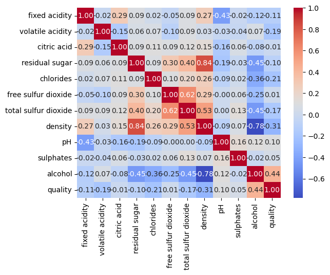

```python
corralation_matrix = white_wine_df.corr()
sns.heatmap(corralation_matrix, annot=True, fmt=".2f", cmap='coolwarm')
```